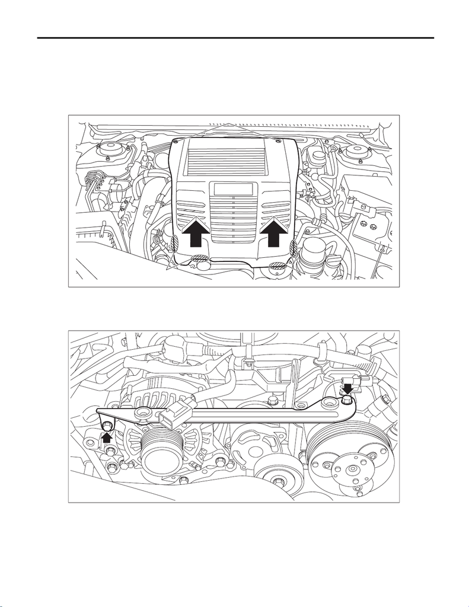

SC(w/o STI)-31

Generator

STARTING/CHARGING SYSTEMS

3. Generator

A: REMOVAL

1) Remove the collector cover.

(1) Remove the clips (A).

(2) Hold the shaded area (B) by hand and carefully pull the RH side (C) upward.

(3) Hold the shaded area (D) by hand and carefully pull the LH side (E) upward.

2) Disconnect the ground terminal from battery sensor. <Ref. to NT-5, BATTERY, NOTE, Note.>

3) Remove the brake booster vacuum pump. <Ref. to BR-81, REMOVAL, Brake Vacuum Pump.>

4) Remove the V-belts. <Ref. to ME(w/o STI)-78, V-BELT, REMOVAL, V-belt.>

5) Remove the collector cover bracket.

EX-03204

(A)

(B)

(C)

(E)

(D)

SC-03063

15WRX_STI_US_EN.book 31 ページ ２０１５年２月１３日 金曜日 午前１１時２０分

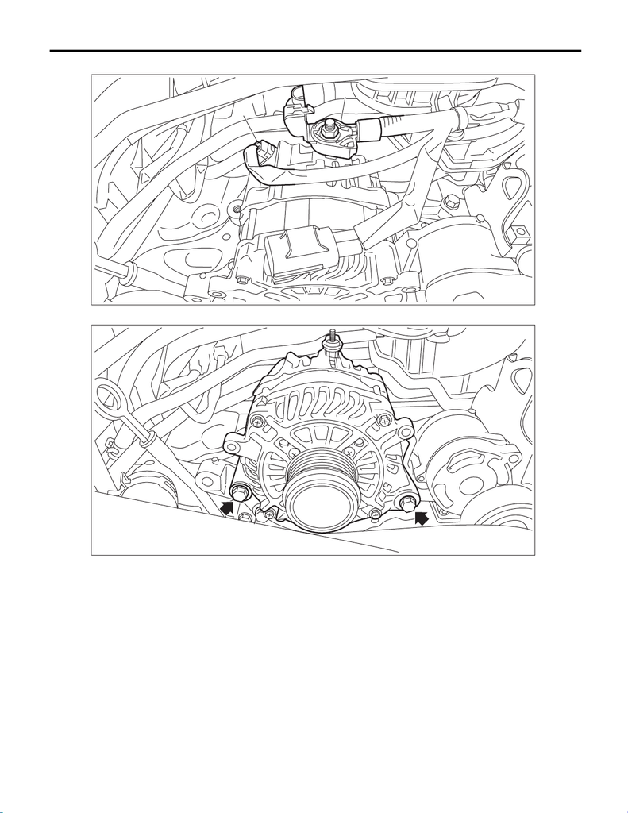

SC(w/o STI)-32

Generator

STARTING/CHARGING SYSTEMS

6) Disconnect the connector (A) and terminal (B) from the generator.

7) Remove the generator from the generator bracket.

8) Remove the V-belt tensioner. <Ref. to ME(w/o STI)-79, V-BELT TENSIONER ASSEMBLY, REMOVAL, V-

belt.>

SC-02881

(A)

(B)

SC-02882

15WRX_STI_US_EN.book 32 ページ ２０１５年２月１３日 金曜日 午前１１時２０分

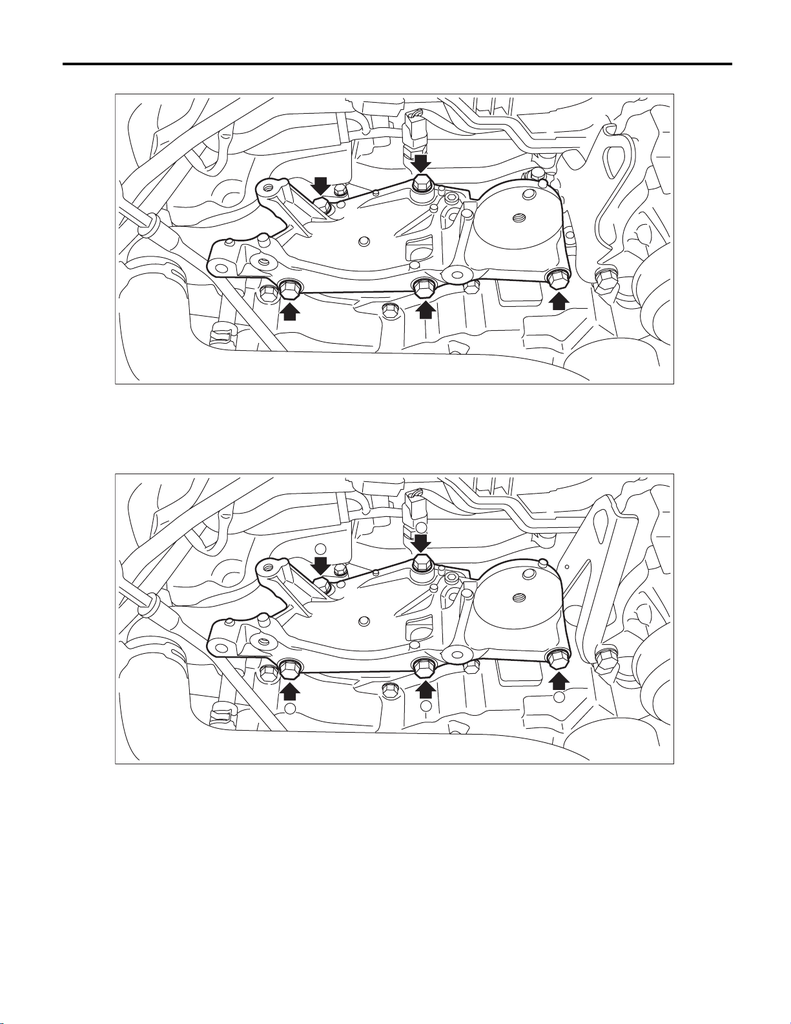

SC(w/o STI)-33

Generator

STARTING/CHARGING SYSTEMS

9) Remove the generator bracket from the engine.

B: INSTALLATION

1) Temporarily install the generator bracket to the engine and tighten the bolts in the numerical order.

Tightening torque:

36 N·m (3.7 kgf-m, 26.6 ft-lb)

2) Install the V-belt tensioner. <Ref. to ME(w/o STI)-82, V-BELT TENSIONER ASSEMBLY, INSTALLATION,

V-belt.>

SC-02883

SC-02762

1

2

3

4

5

15WRX_STI_US_EN.book 33 ページ ２０１５年２月１３日 金曜日 午前１１時２０分

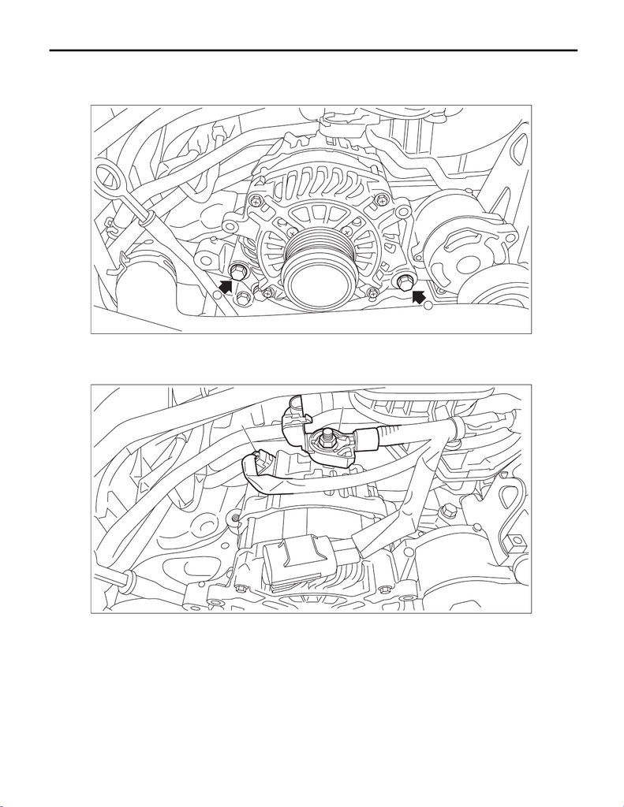

SC(w/o STI)-34

Generator

STARTING/CHARGING SYSTEMS

3) Temporarily install the generator bracket to the generator and tighten the bolts in the numerical order.

Tightening torque:

25 N·m (2.5 kgf-m, 18.4 ft-lb)

4) Connect the connector (A) and terminal (B) to the generator.

Tightening torque:

16 N·m (1.6 kgf-m, 11.8 ft-lb)

SC-02763

1

2

SC-02881

(A)

(B)

15WRX_STI_US_EN.book 34 ページ ２０１５年２月１３日 金曜日 午前１１時２０分

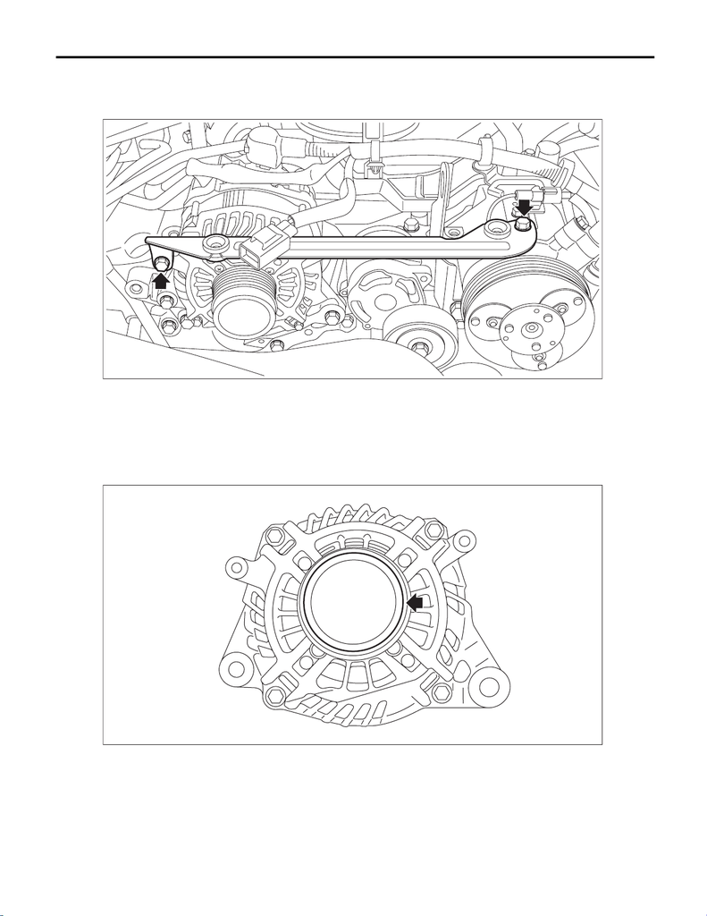

SC(w/o STI)-35

Generator

STARTING/CHARGING SYSTEMS

5) Install the collector cover bracket.

Tightening torque:

6.4 N·m (0.7 kgf-m, 4.7 ft-lb)

6) Install the V-belts. <Ref. to ME(w/o STI)-81, V-BELT, INSTALLATION, V-belt.>

7) Install the brake booster vacuum pump. <Ref. to BR-82, INSTALLATION, Brake Vacuum Pump.>

8) Connect the ground terminal to battery sensor. <Ref. to NT-5, BATTERY, NOTE, Note.>

9) Install the collector cover.

C: DISASSEMBLY

1) Remove the cap from the generator.

SC-03063

SC-02885

15WRX_STI_US_EN.book 35 ページ ２０１５年２月１３日 金曜日 午前１１時２０分

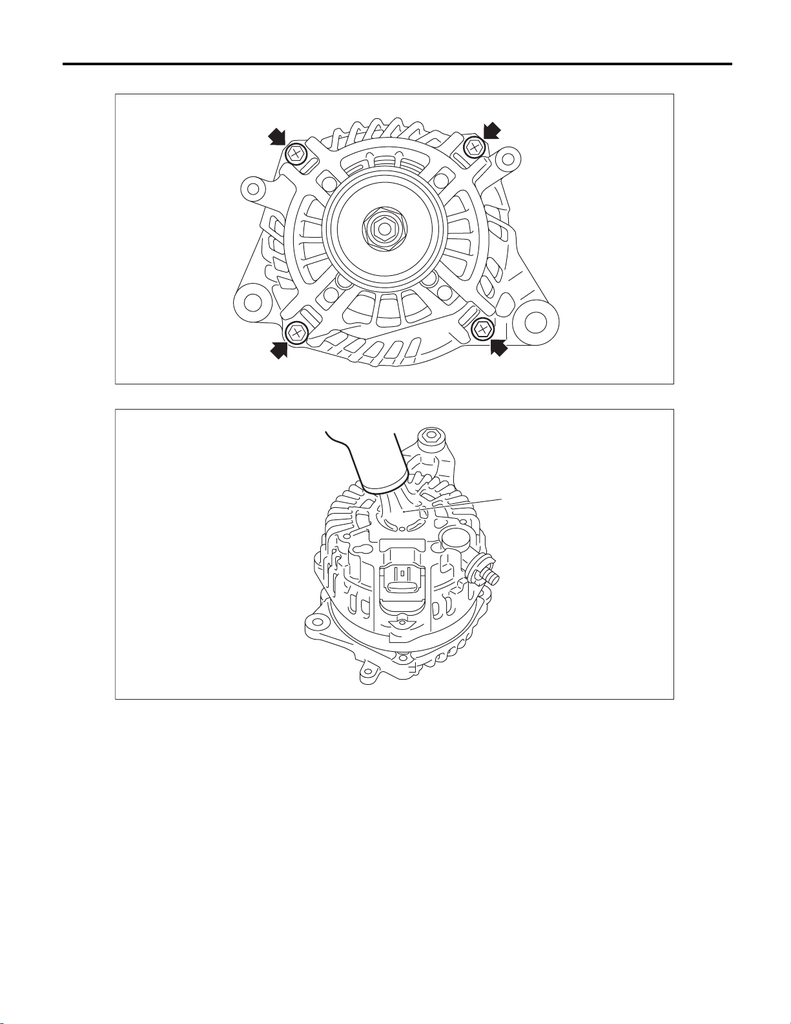

SC(w/o STI)-36

Generator

STARTING/CHARGING SYSTEMS

2) Remove the four through bolts.

3) Use a drier to heat the rear cover (A) portion to 50 — 60°C (122 — 140°F).

SC-02886

SC-02887

(A)

15WRX_STI_US_EN.book 36 ページ ２０１５年２月１３日 金曜日 午前１１時２０分

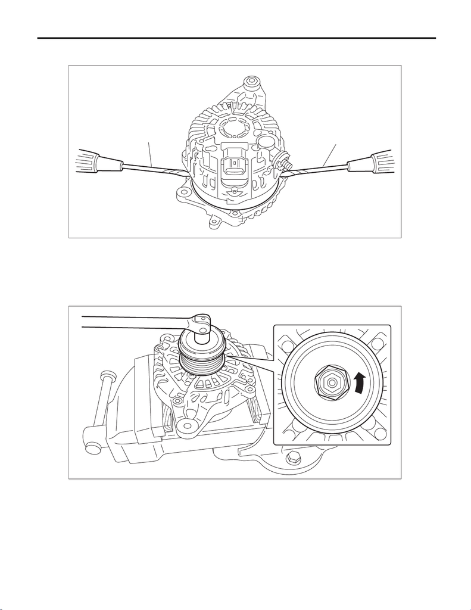

SC(w/o STI)-37

Generator

STARTING/CHARGING SYSTEMS

4) Insert a flat tip screwdriver or similar tool wrapped with protective tape into the gap between stator core

and the front cover to disassemble.

5) Hold the rotor on a vise and remove the pulley.

CAUTION:

When holding the rotor with a vise, place aluminum plates or wooden pieces on the vise jaws to pre-

vent rotor from damage.

(A) Flat tip screwdriver

SC-02946

(A)

(A)

SC-02889

15WRX_STI_US_EN.book 37 ページ ２０１５年２月１３日 金曜日 午前１１時２０分

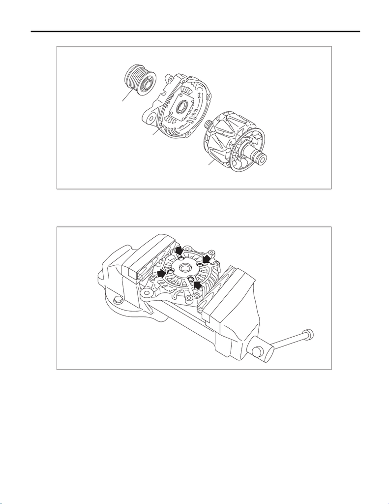

SC(w/o STI)-38

Generator

STARTING/CHARGING SYSTEMS

6) Remove the rotor from the front cover.

7) Use the following procedures to remove the ball bearings.

(1) Remove the bolt, and then detach the bearing retainer.

(A) Pulley (B) Front cover (C) Rotor

SC-02890

(C)

(B)

(A)

SC-02891

15WRX_STI_US_EN.book 38 ページ ２０１５年２月１３日 金曜日 午前１１時２０分

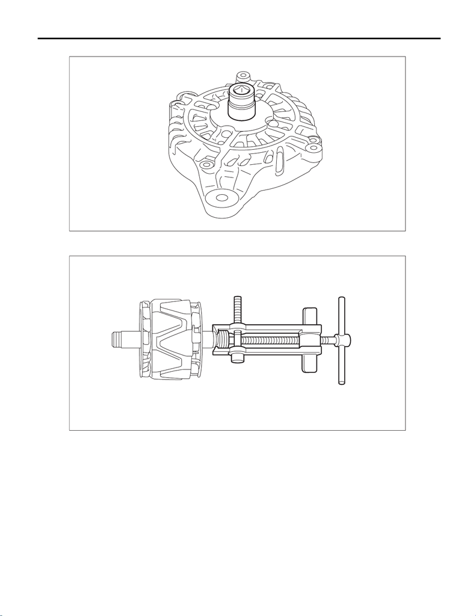

SC(w/o STI)-39

Generator

STARTING/CHARGING SYSTEMS

(2) Firmly attach an appropriate tool (such as a correct size socket wrench) to the bearing inner race.

(3) Use the press to push the ball bearings out from the front cover.

8) Using the bearing puller, remove the bearings from the rotor.

SC-02892

SC-02893

15WRX_STI_US_EN.book 39 ページ ２０１５年２月１３日 金曜日 午前１１時２０分

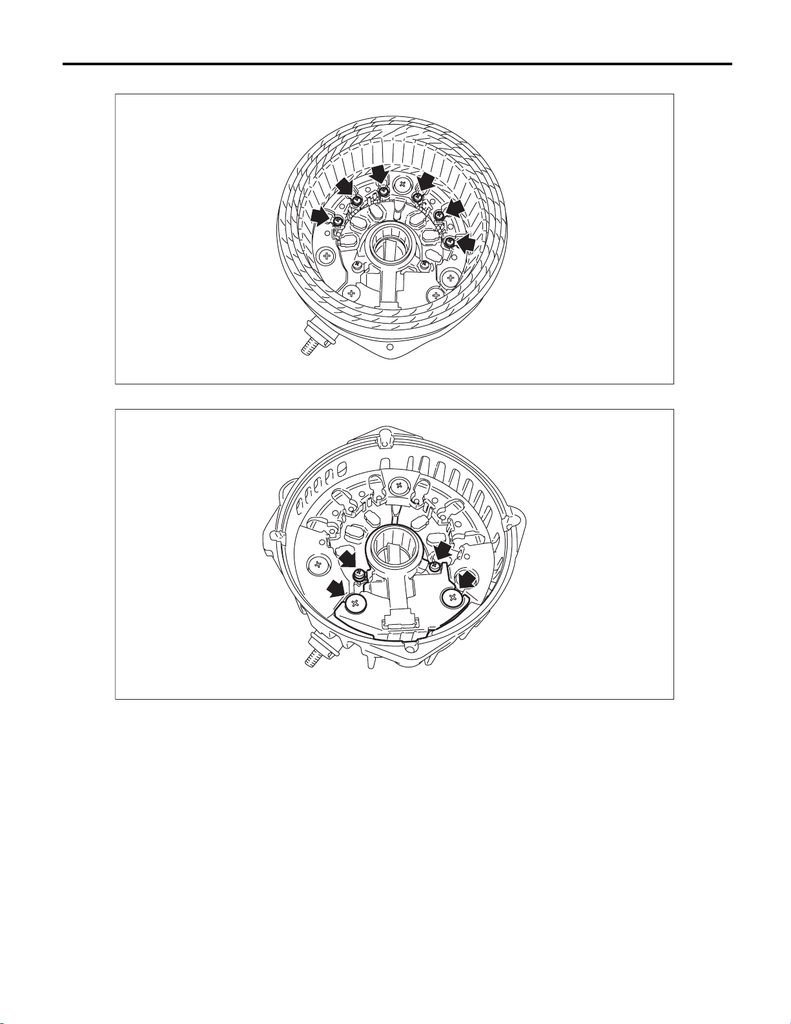

SC(w/o STI)-40

Generator

STARTING/CHARGING SYSTEMS

9) Remove six bolts which connect the rectifier and stator coil, then remove the stator coil.

10) Remove four screws which secure the IC regulator to the rear cover, then remove the IC regulator.

SC-02929

SC-02930

15WRX_STI_US_EN.book 40 ページ ２０１５年２月１３日 金曜日 午前１１時２０分

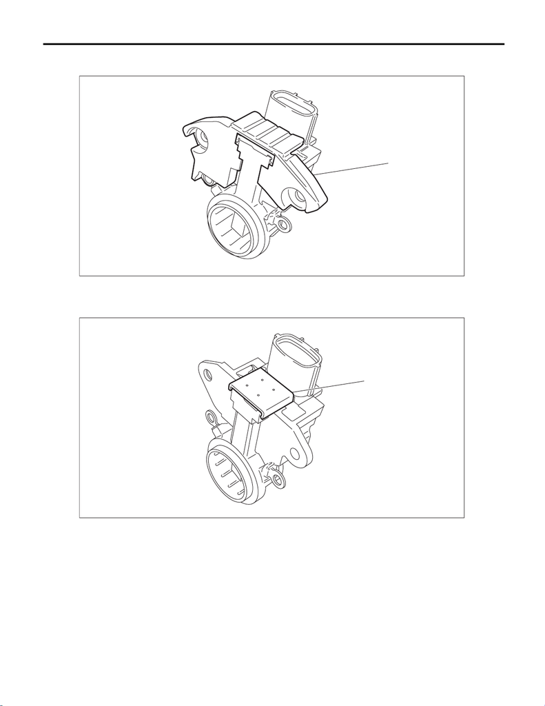

SC(w/o STI)-41

Generator

STARTING/CHARGING SYSTEMS

11) Use the following procedures to remove the brush.

(1) Remove the cover A.

(2) Remove the cover B.

(A) Cover A

(A) Cover B

SC-02944

(A)

SC-02945

(A)

15WRX_STI_US_EN.book 41 ページ ２０１５年２月１３日 金曜日 午前１１時２０分

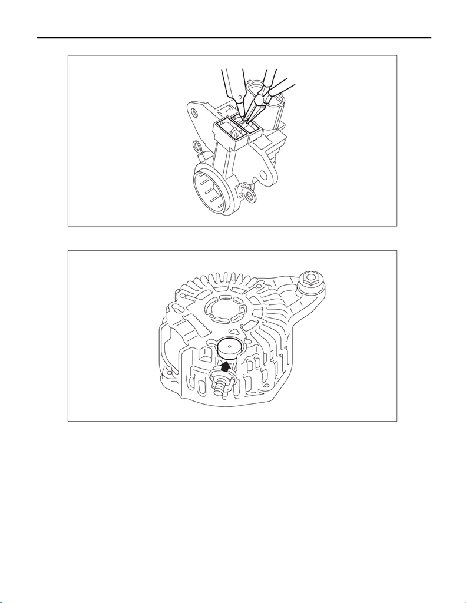

SC(w/o STI)-42

Generator

STARTING/CHARGING SYSTEMS

(3) Disconnect the connection and remove the brush.

12) Remove the rectifier as follows.

(1) Remove the cover on terminal B.

SC-02496

SC-02894

15WRX_STI_US_EN.book 42 ページ ２０１５年２月１３日 金曜日 午前１１時２０分

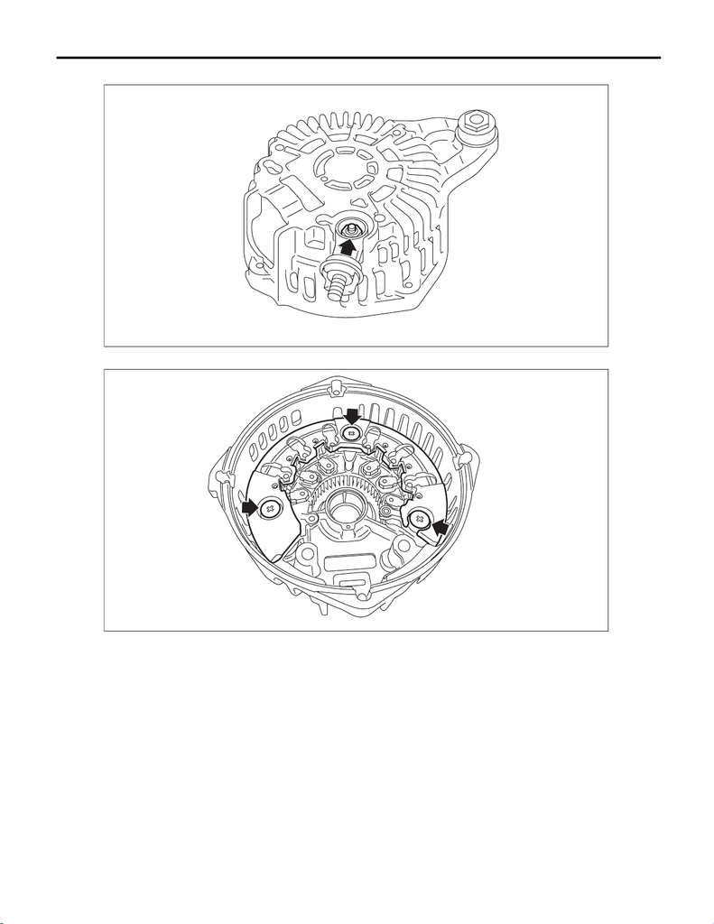

SC(w/o STI)-43

Generator

STARTING/CHARGING SYSTEMS

(2) Remove the nut on terminal B.

(3) Remove the bolts which secure the rectifier, and remove the rectifier.

SC-02895

SC-02931

15WRX_STI_US_EN.book 43 ページ ２０１５年２月１３日 金曜日 午前１１時２０分

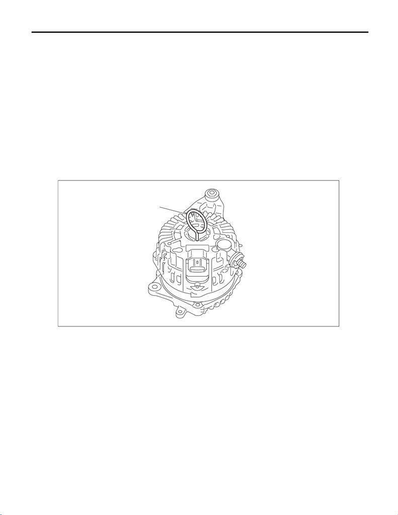

SC(w/o STI)-44

Generator

STARTING/CHARGING SYSTEMS

D: ASSEMBLY

Assemble in the reverse order of disassembly.

NOTE:

• Refer to component for tightening torque of each part. <Ref. to SC(w/o STI)-4, GENERATOR, COMPO-

NENT, General Description.>

• After assembling, manually turn the pulley to check that the rotor rotates smoothly.

1) Assembling the rear cover and rectifier

Remove old silicone grease on the mating surface of rear cover and rectifier and apply new silicone grease.

CAUTION:

Do not apply silicone grease to the attachment threads of rectifier.

2) Push of the brush

Before assembling the front and rear parts, press the brush down into the brush holder, then fix the brush in

that position by inserting a [1 mm (0.0394 in) dia., 40 — 50 mm (1.5748 — 1.9685 in) long] wire through the

hole as shown in the figure.

CAUTION:

After assembling, remove the wire.

3) Install the ball bearings.

(1) Set the ball bearings in the front cover, then securely install an appropriate tool (such as a socket

wrench of proper size) to the bearing outer race.

(2) Using a press to press the ball bearings into the specified location.

(3) Install the bearing retainer.

4) Install the bearings.

CAUTION:

Do not apply grease to the bearings. If there is any oil on the bearing box, remove it completely.

(1) Use a press to install the bearings to the rotor shaft.

(2) Heat the bearing box in rear cover at 50 to 60°C (122 to 140°F), and then press the bearing into rear

cover.

(A) Wire

SC-02896

(A)

15WRX_STI_US_EN.book 44 ページ ２０１５年２月１３日 金曜日 午前１１時２０分

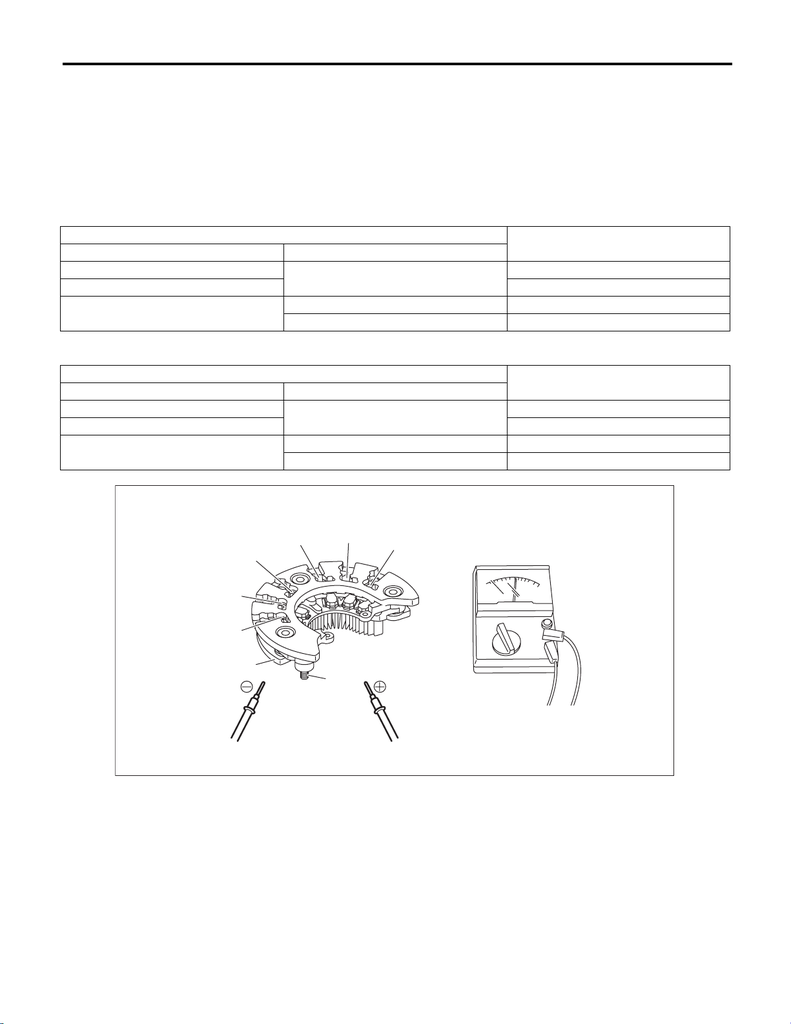

SC(w/o STI)-45

Generator

STARTING/CHARGING SYSTEMS

E: INSPECTION

1. DIODE

CAUTION:

There is the possibility of damaging the diodes if a mega-tester (used to measure high voltages) or

a similar measuring instrument is used. Never use a mega tester or equivalent for this test.

1) Check for continuity between the diode lead and terminal E or B. If continuity is not as shown in the table,

replace the rectifier.

• At analog type tester

• At digital type tester

Tester lead

Continuity

–lead +lead

E

P1, P2, P3, P4, P5, P6

Ye s

B No

P1, P2, P3, P4, P5, P6

ENo

BYes

Tester lead

Continuity

–lead +lead

E

P1, P2, P3, P4, P5, P6

No

B Ye s

P1, P2, P3, P4, P5, P6

EYes

BNo

SC-02508

P1

P6

P5

P4

P3

P2

E

B

15WRX_STI_US_EN.book 45 ページ ２０１５年２月１３日 金曜日 午前１１時２０分

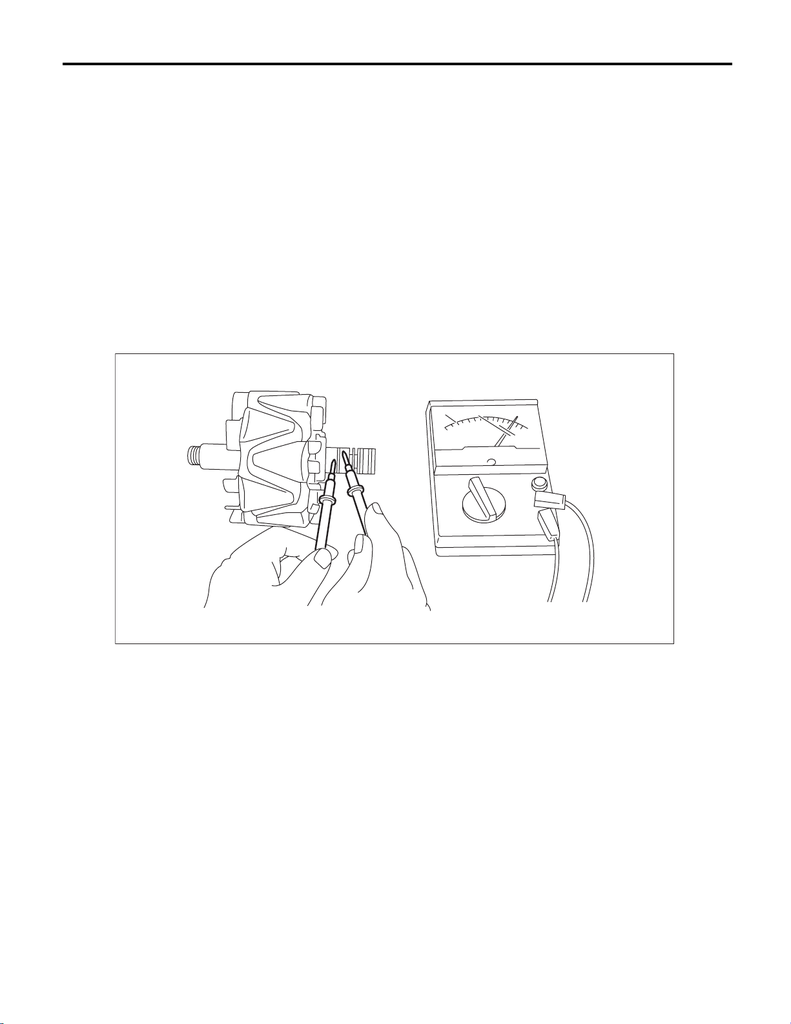

SC(w/o STI)-46

Generator

STARTING/CHARGING SYSTEMS

2. ROTOR

1) Slip ring surface

Inspect the slip rings for contamination or any roughness on the sliding surface. Repair the slip ring surface

using a lathe or sand paper.

2) Slip ring outer diameter

Measure the slip ring outer diameter. Replace the rotor if the slip ring is worn.

Slip ring outer diameter:

Standard

22.7 mm (0.894 in)

Limit

22.1 mm (0.870 in)

3) Continuity test

Using a circuit tester, check the resistance between slip rings. If the resistance is not within the standard, re-

place the rotor.

Standard:

Approx. 2.0 — 2.4

Ω

SC-02501

15WRX_STI_US_EN.book 46 ページ ２０１５年２月１３日 金曜日 午前１１時２０分

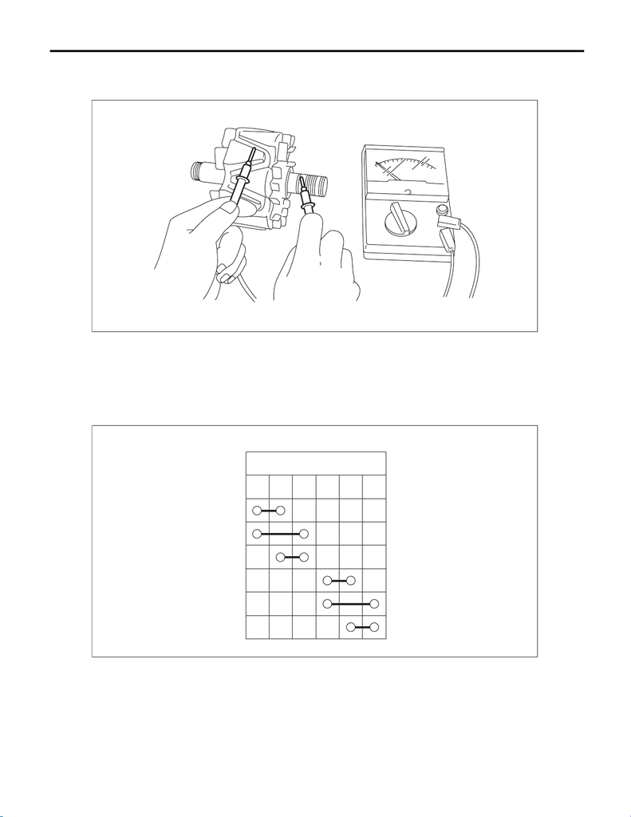

SC(w/o STI)-47

Generator

STARTING/CHARGING SYSTEMS

4) Insulation test

Check the continuity between slip ring and rotor core or shaft. If there is continuity, replace the rotor because

the rotor coil is grounded.

5) Bearing

Check the bearings. If there is any noise, or the rotor does not rotate smoothly, replace the bearings.

3. STATOR COIL

1) Continuity test

Inspect the continuity between the stator coil terminals. If continuity is not as shown in the table, replace the

stator coil.

(A) Terminals

SC-02502

SC-02503

123456

(A)

15WRX_STI_US_EN.book 47 ページ ２０１５年２月１３日 金曜日 午前１１時２０分

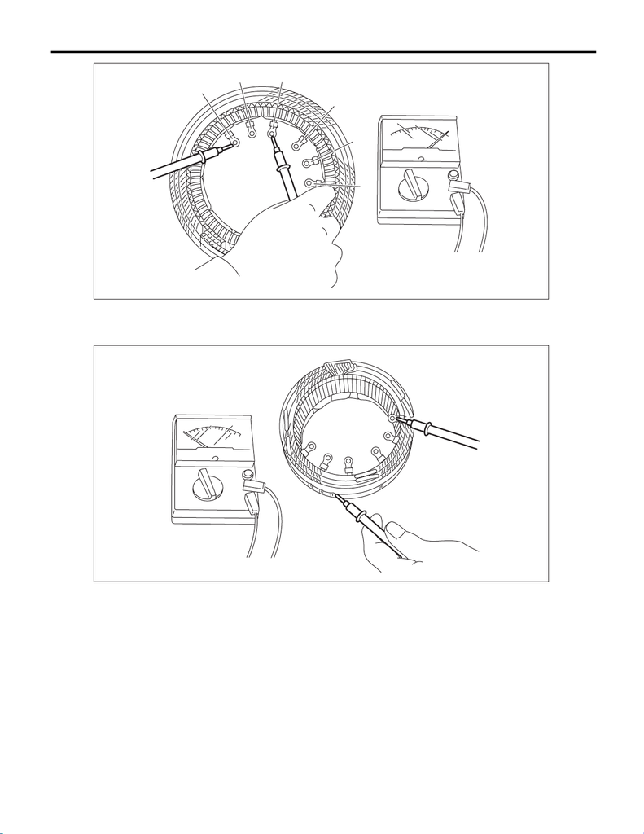

SC(w/o STI)-48

Generator

STARTING/CHARGING SYSTEMS

2) Insulation test

Inspect the continuity between the stator coil stator core and lead wire terminals. If there is continuity, replace

the stator coil because the stator coil is grounded.

SC-02504

1

23

4

5

6

SC-02505

15WRX_STI_US_EN.book 48 ページ ２０１５年２月１３日 金曜日 午前１１時２０分

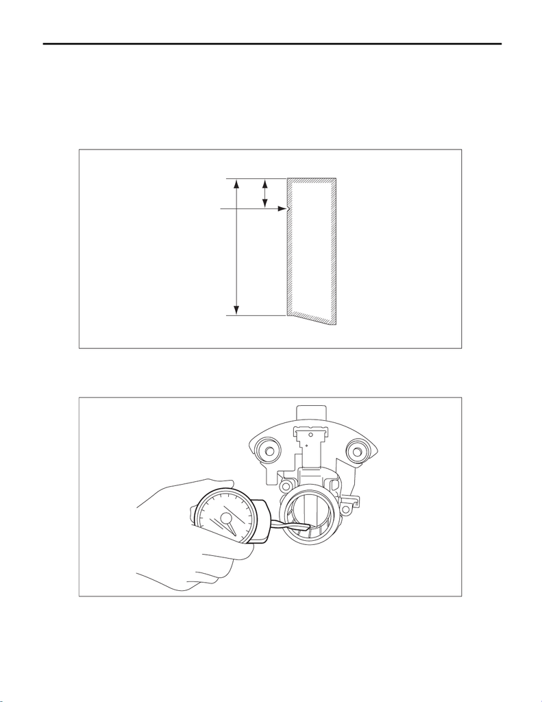

SC(w/o STI)-49

Generator

STARTING/CHARGING SYSTEMS

4. BRUSH

1) Measure the length of each brush. Replace the brush if wear exceeds service limits. There is a service limit

mark (A) on each brush.

Brush length:

Standard (1)

22.5 mm (0.886 in)

Limit (2)

5.0 mm (0.197 in)

2) Check that there is appropriate pressure on the brush spring. Using a spring pressure indicator, push the

brush into the brush holder until its tip protrudes 2 mm (0.0787 in). Then measure the pressure of brush

spring. If the pressure is 1.7 N (173 gf, 6.11 ozf) or less, replace the brush spring. 4.1 — 5.3 N (418 — 540

gf, 14.75 — 19.06 ozf) pressure is required on the new spring.

5. BALL BEARING

Check the ball bearings. Replace the ball bearings if there is resistance in the rotation, or if there is any ab-

normal noise.

SC-02506

(A)

(1)

(2)

SC-02507

15WRX_STI_US_EN.book 49 ページ ２０１５年２月１３日 金曜日 午前１１時２０分